# Estatines intensitat

Eudald Correig

26/6/2020

# Formateig

Traiem les resines i l’omacor perquè tenen massa poca variabilitat.

Nota: canvio el nom d’Antiagregants.Anticoagulants a A.A perquè si no ocupa massa i les coses es veuen malament.

Mirem quantes dates d’ingrés o alta ens falten:

Hi ha 2 pacients dels quals no tenim la data d’ingrés. Els traiem.

Fem una variable que controla quin esdeveniment de sortida (outcome) té cada pacient:

Hi ha encara algun pacient que té 0 dies d’estada:

```
##  [1] "3-093"  "3-099"  "09-101" "09-120" "10-107" "11-044" "13-129"
##  [8] "13-197" "19-022" "20-074"
```

Sumem un dia a tots

Traiem els pacients que tenen pes 0.

# Anàlisi univariant

Fem un test de chi^2 per entre prendre estatines o no i morir de covid o no:

```
##
##
##    Cell Contents
## |-------------------------|
## |                       N |
## | Chi-square contribution |
## |           N / Row Total |
## |           N / Col Total |
## |         N / Table Total |
## |-------------------------|
##
##
## Total Observations in Table:  1167
##
##
##              |        No |        Sí | Row Total |
## -------------|-----------|-----------|-----------|
##           no |       451 |       133 |       584 |
##              |     0.153 |     0.565 |           |
##              |     0.772 |     0.228 |     0.500 |
##              |     0.491 |     0.534 |           |
##              |     0.386 |     0.114 |           |
## -------------|-----------|-----------|-----------|
##        baixa |       324 |        81 |       405 |
##              |     0.092 |     0.339 |           |
##              |     0.800 |     0.200 |     0.347 |
##              |     0.353 |     0.325 |           |
##              |     0.278 |     0.069 |           |
## -------------|-----------|-----------|-----------|
##         alta |       143 |        35 |       178 |
##              |     0.063 |     0.234 |           |
##              |     0.803 |     0.197 |     0.153 |
##              |     0.156 |     0.141 |           |
##              |     0.123 |     0.030 |           |
## -------------|-----------|-----------|-----------|
## Column Total |       918 |       249 |      1167 |
##              |     0.787 |     0.213 |           |
## -------------|-----------|-----------|-----------|
##
##
## Statistics for All Table Factors
##
##
## Pearson's Chi-squared test
## ------------------------------------------------------------
## Chi^2 =  1.447025     d.f. =  2     p =  0.4850456
##
##
##
```

Fem un gràfic:

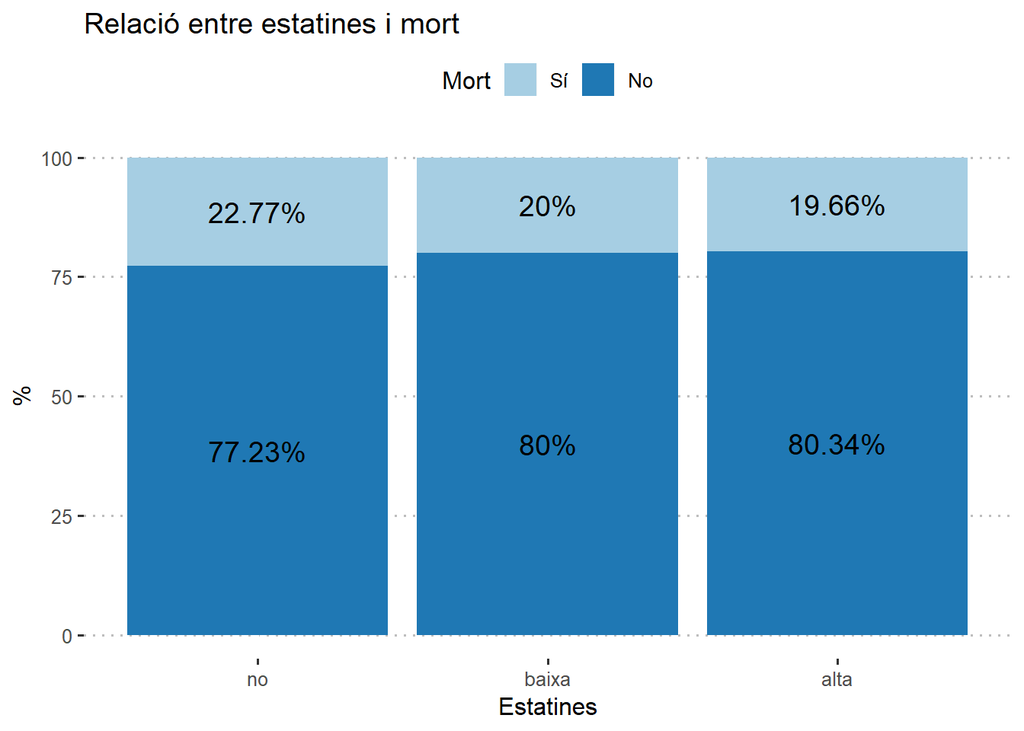

# Model de supervivència

Primer dibuixem una Kaplan Meier:

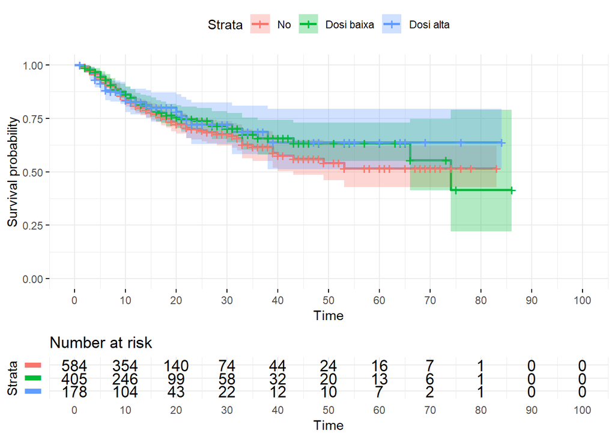

## Cause specific hazard ratio

Tenim els següents esdeveniments:

```
##
## censura    alta    mort
##      14     904     249
```

### Mort

```
## Call:
## coxph(formula = Surv(as.numeric(temps), esdeveniment == "mort") ~
##     . - Mort - weights - Sexe + strata(Sexe), data = df, weights = df$weights,
##     ties = "efron")
##
##   n= 1167, number of events= 249
##
##                     coef exp(coef)  se(coef)      z Pr(>|z|)
## Edat            0.063918  1.066005  0.007499  8.523  < 2e-16 ***
## TabacExfumador  0.113074  1.119715  0.169036  0.669  0.50354
## TabacSí         0.235146  1.265093  0.319927  0.735  0.46234
## HTASí           0.140766  1.151155  0.187772  0.750  0.45346
## HiperlipemiaSí  0.387047  1.472626  0.170632  2.268  0.02331 *
## DiabetesSí      0.037329  1.038035  0.227994  0.164  0.86994
## ObesitatSí      0.057799  1.059502  0.149916  0.386  0.69984
## Ant.CISí       -0.210555  0.810134  0.187419 -1.123  0.26125
## Ant.IctusSí    -0.040233  0.960565  0.197023 -0.204  0.83819
## Ant.MVPSí       0.328578  1.388991  0.201773  1.628  0.10343
## Ant.Ins.CardSí  0.292858  1.340253  0.174831  1.675  0.09392 .
## Ant.MPOCSí     -0.081266  0.921949  0.158470 -0.513  0.60808
## Ant.MHepCSí    -0.266154  0.766321  0.445605 -0.597  0.55032
## Ant.MRCSí       0.084504  1.088178  0.158464  0.533  0.59385
## Ant.MReuSí      0.166039  1.180619  0.264061  0.629  0.52949
## CàncerSí        0.505513  1.657837  0.167767  3.013  0.00259 **
## Estatinesbaixa -0.208242  0.812010  0.170565 -1.221  0.22213
## Estatinesalta  -0.283799  0.752918  0.239633 -1.184  0.23629
## EzetimibaSí     0.087575  1.091524  0.383361  0.228  0.81930
## FibratSí        0.766557  2.152342  0.306618  2.500  0.01242 *
## IECASí         -0.266383  0.766145  0.158635 -1.679  0.09311 .
## ARA2Sí         -0.435346  0.647041  0.194789 -2.235  0.02542 *
## InsulinaSí      0.400638  1.492777  0.214184  1.871  0.06141 .
## ISGLT2Sí       -0.382695  0.682021  0.470373 -0.814  0.41587
## GLP1Sí          0.143436  1.154233  0.360125  0.398  0.69041
## Trac.DMSí       0.135125  1.144680  0.211089  0.640  0.52209
## A.A.NACOs      -0.168416  0.845002  0.254117 -0.663  0.50749
## A.A.No         -0.166725  0.846433  0.166292 -1.003  0.31605
## A.A.Sintrom    -0.270161  0.763256  0.230725 -1.171  0.24163
## CT              0.046397  1.047491  0.112956  0.411  0.68125
## HDL             0.274951  1.316466  0.244664  1.124  0.26110
## LDL            -0.164546  0.848279  0.146137 -1.126  0.26018
```

[output cut: 28 more lines]

```
## ISGLT2Sí          0.6820     1.4662    0.2713    1.7147
## GLP1Sí            1.1542     0.8664    0.5698    2.3379
## Trac.DMSí         1.1447     0.8736    0.7568    1.7313
## A.A.NACOs         0.8450     1.1834    0.5135    1.3905
## A.A.No            0.8464     1.1814    0.6110    1.1726
## A.A.Sintrom       0.7633     1.3102    0.4856    1.1997
## CT                1.0475     0.9547    0.8395    1.3071
## HDL               1.3165     0.7596    0.8150    2.1265
## LDL               0.8483     1.1789    0.6370    1.1296
## TG                1.0265     0.9741    0.9375    1.1241
##
## Concordance= 0.747  (se = 0.015 )
## Likelihood ratio test= 164.9  on 33 df,   p=<2e-16
## Wald test            = 147.2  on 33 df,   p=2e-16
## Score (logrank) test = 157.4  on 33 df,   p=<2e-16
```

Forest plot:

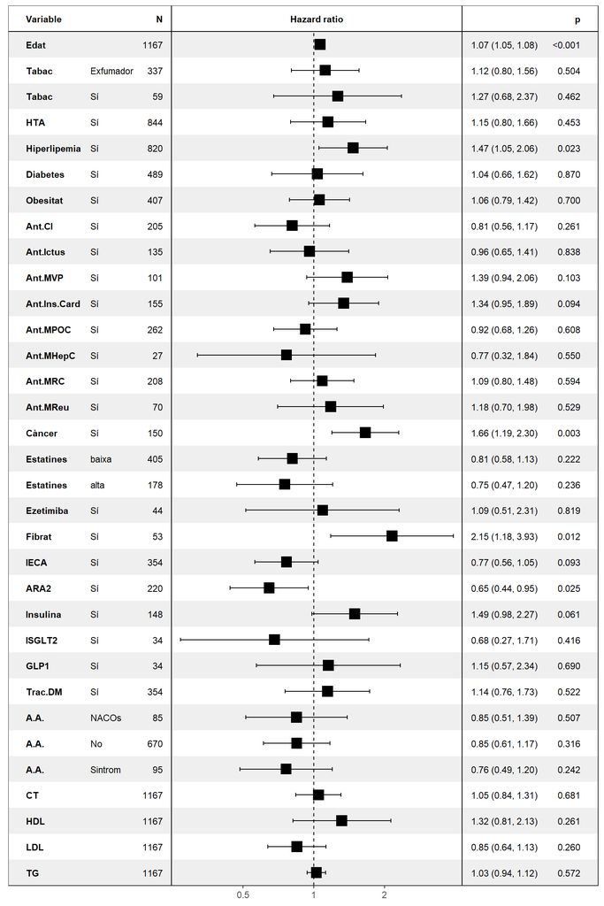

### Alta

```
## Call:
## coxph(formula = Surv(as.numeric(temps), df$esdeveniment == "alta") ~
##     . - weights - Mort, data = df, weights = df$weights, ties = "efron")
##
##   n= 1167, number of events= 904
##
##                     coef exp(coef)  se(coef)      z Pr(>|z|)
## Edat           -0.011229  0.988834  0.003324 -3.379 0.000729 ***
## SexeHome       -0.147101  0.863207  0.079926 -1.840 0.065700 .
## TabacExfumador -0.038792  0.961951  0.086170 -0.450 0.652583
## TabacSí        -0.147943  0.862480  0.165660 -0.893 0.371829
## HTASí           0.048367  1.049556  0.096211  0.503 0.615160
## HiperlipemiaSí -0.087251  0.916447  0.088244 -0.989 0.322784
## DiabetesSí     -0.033855  0.966711  0.123665 -0.274 0.784263
## ObesitatSí     -0.038683  0.962056  0.076957 -0.503 0.615206
## Ant.CISí        0.039267  1.040048  0.106555  0.369 0.712490
## Ant.IctusSí     0.073507  1.076276  0.120577  0.610 0.542110
## Ant.MVPSí      -0.289924  0.748321  0.133948 -2.164 0.030430 *
## Ant.Ins.CardSí -0.068522  0.933773  0.123212 -0.556 0.578125
## Ant.MPOCSí      0.109978  1.116253  0.086729  1.268 0.204776
## Ant.MHepCSí    -0.053210  0.948181  0.232544 -0.229 0.819011
## Ant.MRCSí       0.016022  1.016151  0.103888  0.154 0.877432
## Ant.MReuSí     -0.242799  0.784429  0.146362 -1.659 0.097138 .
## CàncerSí       -0.052716  0.948649  0.108551 -0.486 0.627228
## Estatinesbaixa  0.035489  1.036126  0.086053  0.412 0.680043
## Estatinesalta   0.127157  1.135595  0.122060  1.042 0.297524
## EzetimibaSí     0.297946  1.347089  0.183857  1.621 0.105119
## FibratSí       -0.203886  0.815555  0.175970 -1.159 0.246602
## IECASí          0.097203  1.102085  0.091339  1.064 0.287237
## ARA2Sí         -0.015187  0.984928  0.104106 -0.146 0.884019
## InsulinaSí     -0.103868  0.901344  0.127826 -0.813 0.416462
## ISGLT2Sí        0.012683  1.012763  0.203221  0.062 0.950238
## GLP1Sí          0.247373  1.280656  0.214155  1.155 0.248046
## Trac.DMSí       0.020999  1.021221  0.119923  0.175 0.860999
## A.A.NACOs      -0.020060  0.980140  0.150326 -0.133 0.893844
## A.A.No         -0.045103  0.955899  0.097532 -0.462 0.643763
## A.A.Sintrom    -0.207244  0.812821  0.147100 -1.409 0.158877
## CT             -0.070765  0.931681  0.087033 -0.813 0.416171
## HDL             0.288466  1.334379  0.139377  2.070 0.038482 *
## LDL             0.064808  1.066954  0.098516  0.658 0.510641
```

[output cut: 29 more lines]

```
## ISGLT2Sí          1.0128     0.9874    0.6800    1.5083
## GLP1Sí            1.2807     0.7808    0.8417    1.9486
## Trac.DMSí         1.0212     0.9792    0.8073    1.2918
## A.A.NACOs         0.9801     1.0203    0.7300    1.3160
## A.A.No            0.9559     1.0461    0.7896    1.1573
## A.A.Sintrom       0.8128     1.2303    0.6092    1.0844
## CT                0.9317     1.0733    0.7856    1.1050
## HDL               1.3344     0.7494    1.0154    1.7535
## LDL               1.0670     0.9372    0.8796    1.2942
## TG                0.9857     1.0145    0.9382    1.0357
##
## Concordance= 0.578  (se = 0.011 )
## Likelihood ratio test= 46.2  on 34 df,   p=0.08
## Wald test            = 45.29  on 34 df,   p=0.09
## Score (logrank) test = 45.44  on 34 df,   p=0.09
```

Forest plot:

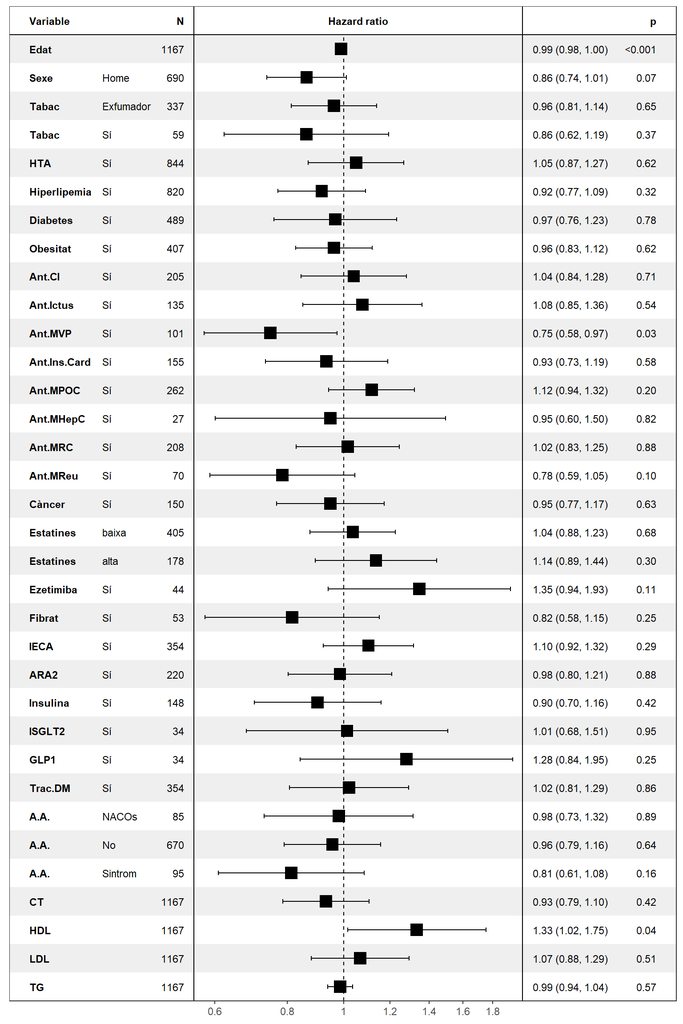

I acabem per un competing risk

## Competing risk

### Mort

```
## Call:
## coxph(formula = Surv(fgstart, fgstop, fgstatus) ~ . - Mort -
##     fgwt - weights, data = fg, weights = fgwt)
##
##   n= 3794, number of events= 249
##
##                    coef exp(coef) se(coef) robust se      z Pr(>|z|)
## Edat            0.06479   1.06693  0.00743   0.00678  9.557  < 2e-16 ***
## SexeHome        0.26979   1.30969  0.15799   0.15773  1.711  0.08717 .
## TabacExfumador  0.12346   1.13141  0.16835   0.17499  0.706  0.48048
## TabacSí         0.38790   1.47388  0.31265   0.32137  1.207  0.22742
## HTASí           0.10235   1.10777  0.18851   0.18983  0.539  0.58978
## HiperlipemiaSí  0.38128   1.46415  0.17029   0.17573  2.170  0.03003 *
## DiabetesSí      0.09401   1.09857  0.22374   0.23547  0.399  0.68972
## ObesitatSí      0.10278   1.10825  0.14674   0.14967  0.687  0.49225
## Ant.CISí       -0.27268   0.76134  0.18418   0.19016 -1.434  0.15160
## Ant.IctusSí    -0.07970   0.92339  0.19532   0.20524 -0.388  0.69776
## Ant.MVPSí       0.36234   1.43669  0.20204   0.20478  1.769  0.07683 .
## Ant.Ins.CardSí  0.30040   1.35040  0.17204   0.17880  1.680  0.09295 .
## Ant.MPOCSí     -0.11917   0.88766  0.15660   0.16291 -0.731  0.46449
## Ant.MHepCSí    -0.32705   0.72105  0.44392   0.48850 -0.669  0.50319
## Ant.MRCSí       0.10837   1.11446  0.15748   0.16627  0.652  0.51455
## Ant.MReuSí      0.28897   1.33506  0.26091   0.26660  1.084  0.27840
## CàncerSí        0.45652   1.57857  0.16688   0.17273  2.643  0.00822 **
## Estatinesbaixa -0.25923   0.77165  0.17107   0.17485 -1.483  0.13818
## Estatinesalta  -0.27511   0.75949  0.23388   0.24438 -1.126  0.26028
## EzetimibaSí    -0.20400   0.81546  0.37925   0.41413 -0.493  0.62230
## FibratSí        0.74350   2.10329  0.30564   0.30978  2.400  0.01639 *
## IECASí         -0.24612   0.78183  0.15853   0.16736 -1.471  0.14141
## ARA2Sí         -0.41640   0.65942  0.19271   0.19614 -2.123  0.03375 *
## InsulinaSí      0.38922   1.47582  0.21210   0.22734  1.712  0.08689 .
## ISGLT2Sí       -0.26756   0.76524  0.47299   0.49885 -0.536  0.59171
## GLP1Sí          0.09832   1.10331  0.36045   0.40321  0.244  0.80736
## Trac.DMSí       0.10267   1.10813  0.21055   0.22207  0.462  0.64385
## A.A.NACOs      -0.09111   0.91292  0.24902   0.24768 -0.368  0.71299
## A.A.No         -0.10940   0.89637  0.16713   0.17665 -0.619  0.53573
## A.A.Sintrom    -0.16234   0.85015  0.23073   0.23316 -0.696  0.48626
## CT              0.05160   1.05296  0.11024   0.11427  0.452  0.65158
## HDL             0.12011   1.12762  0.23503   0.21119  0.569  0.56954
## LDL            -0.13885   0.87036  0.14216   0.13893 -0.999  0.31760
```

[output cut: 32 more lines]

```
## A.A.NACOs         0.9129     1.0954    0.5618    1.4834
## A.A.No            0.8964     1.1156    0.6340    1.2672
## A.A.Sintrom       0.8502     1.1763    0.5383    1.3426
## CT                1.0530     0.9497    0.8417    1.3173
## HDL               1.1276     0.8868    0.7454    1.7058
## LDL               0.8704     1.1490    0.6629    1.1428
## TG                1.0190     0.9813    0.9355    1.1100
##
## Concordance= 0.735  (se = 0.014 )
## Likelihood ratio test= 173.2  on 34 df,   p=<2e-16
## Wald test            = 195.2  on 34 df,   p=<2e-16
## Score (logrank) test = 163.2  on 34 df,   p=<2e-16,   Robust = 147.2  p=5e-16
##
##   (Note: the likelihood ratio and score tests assume independence of
##      observations within a cluster, the Wald and robust score tests do not).
```

### Alta

```
## Call:
## coxph(formula = Surv(fgstart, fgstop, fgstatus) ~ . - Mort -
##     fgwt - weights, data = fg, weights = fgwt)
##
##   n= 3143, number of events= 904
##
##                     coef exp(coef)  se(coef) robust se      z Pr(>|z|)
## Edat           -0.028466  0.971935  0.003232  0.003283 -8.671  < 2e-16 ***
## SexeHome       -0.178144  0.836822  0.078753  0.071123 -2.505  0.01225 *
## TabacExfumador -0.060409  0.941379  0.085636  0.077551 -0.779  0.43600
## TabacSí        -0.156152  0.855429  0.164095  0.137259 -1.138  0.25527
## HTASí          -0.038599  0.962136  0.094647  0.082991 -0.465  0.64186
## HiperlipemiaSí -0.170149  0.843539  0.086987  0.080836 -2.105  0.03530 *
## DiabetesSí     -0.035165  0.965446  0.119146  0.109571 -0.321  0.74826
## ObesitatSí     -0.062263  0.939636  0.075855  0.070564 -0.882  0.37758
## Ant.CISí        0.079685  1.082946  0.106679  0.099232  0.803  0.42196
## Ant.IctusSí     0.010292  1.010345  0.118748  0.109540  0.094  0.92514
## Ant.MVPSí      -0.309915  0.733509  0.134367  0.121432 -2.552  0.01071 *
## Ant.Ins.CardSí -0.200305  0.818481  0.120803  0.115447 -1.735  0.08273 .
## Ant.MPOCSí      0.071209  1.073805  0.085520  0.077284  0.921  0.35685
## Ant.MHepCSí     0.027603  1.027988  0.229593  0.197271  0.140  0.88872
## Ant.MRCSí      -0.049933  0.951293  0.102150  0.093838 -0.532  0.59464
## Ant.MReuSí     -0.189431  0.827430  0.145331  0.129786 -1.460  0.14441
## CàncerSí       -0.196093  0.821936  0.107500  0.097862 -2.004  0.04510 *
## Estatinesbaixa  0.106154  1.111993  0.086272  0.079365  1.338  0.18105
## Estatinesalta   0.224947  1.252257  0.119760  0.108363  2.076  0.03791 *
## EzetimibaSí     0.239137  1.270152  0.182322  0.171040  1.398  0.16207
## FibratSí       -0.369197  0.691289  0.175920  0.148680 -2.483  0.01302 *
## IECASí          0.228549  1.256776  0.089208  0.080699  2.832  0.00462 **
## ARA2Sí          0.177467  1.194188  0.102545  0.093867  1.891  0.05867 .
## InsulinaSí     -0.220370  0.802222  0.124358  0.107206 -2.056  0.03982 *
## ISGLT2Sí        0.132966  1.142211  0.200863  0.145721  0.912  0.36152
## GLP1Sí          0.095857  1.100601  0.211139  0.181816  0.527  0.59804
## Trac.DMSí      -0.008221  0.991813  0.116754  0.103841 -0.079  0.93690
## A.A.NACOs       0.081042  1.084416  0.148145  0.129799  0.624  0.53239
## A.A.No          0.010494  1.010549  0.096606  0.088617  0.118  0.90573
## A.A.Sintrom     0.029454  1.029892  0.147194  0.133129  0.221  0.82490
## CT             -0.077424  0.925497  0.084335  0.091055 -0.850  0.39516
## HDL             0.212397  1.236639  0.140202  0.142700  1.488  0.13664
## LDL             0.101144  1.106436  0.096168  0.101052  1.001  0.31687
```

[output cut: 32 more lines]

```
## A.A.NACOs         1.0844     0.9222    0.8408    1.3986
## A.A.No            1.0105     0.9896    0.8494    1.2022
## A.A.Sintrom       1.0299     0.9710    0.7934    1.3369
## CT                0.9255     1.0805    0.7742    1.1063
## HDL               1.2366     0.8086    0.9349    1.6357
## LDL               1.1064     0.9038    0.9076    1.3488
## TG                0.9876     1.0126    0.9431    1.0341
##
## Concordance= 0.61  (se = 0.01 )
## Likelihood ratio test= 156.4  on 34 df,   p=<2e-16
## Wald test            = 145.6  on 34 df,   p=9e-16
## Score (logrank) test = 159.1  on 34 df,   p=<2e-16,   Robust = 161.2  p=<2e-16
##
##   (Note: the likelihood ratio and score tests assume independence of
##      observations within a cluster, the Wald and robust score tests do not).
```